# part_1

```
Downloading: "https://download.pytorch.org/models/vit_b_16-c867db91.pth" to /home/batorgil/.cache/torch/hub/checkpoints/vit_b_16-c867db91.pth
```

```
torch 2.0.0+cu117 | torchvision 0.15.1+cu117
checkpoint: ViT_B_16_Weights.IMAGENET1K_V1
device: cpu
ImageClassification(
    crop_size=[224]
    resize_size=[256]
    mean=[0.485, 0.456, 0.406]
    std=[0.229, 0.224, 0.225]
    interpolation=InterpolationMode.BILINEAR
)
```

```
image tensor: (3, 224, 224)
patches: 196  (14x14 grid)
sequence length with CLS token: 197
```

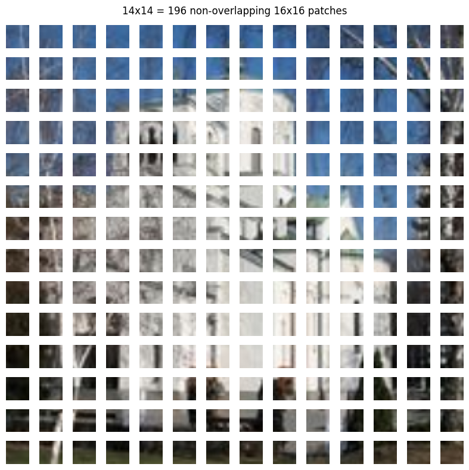

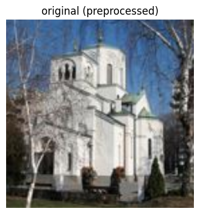

```
english_springer     -> ImageNet index  217  'English springer'
chain_saw            -> ImageNet index  491  'chain saw'
church               -> ImageNet index  497  'church'
garbage_truck        -> ImageNet index  569  'garbage truck'
golf_ball            -> ImageNet index  574  'golf ball'

20 images
```

```
[OK ] english_springer/ILSVRC2012_val_00000665.JPEG   (true: English springer)
    1. English springer                    0.8068
    2. Welsh springer spaniel              0.0195
    3. Sussex spaniel                      0.0076
    4. cocker spaniel                      0.0062
    5. clumber                             0.0052

[OK ] english_springer/ILSVRC2012_val_00001968.JPEG   (true: English springer)
    1. English springer                    0.5764
    2. Sussex spaniel                      0.1010
    3. Welsh springer spaniel              0.0857
    4. English setter                      0.0231
    5. clumber                             0.0184

[OK ] english_springer/ILSVRC2012_val_00002294.JPEG   (true: English springer)
    1. English springer                    0.3858
    2. Bernese mountain dog                0.3213
    3. Appenzeller                         0.0254
    4. Sussex spaniel                      0.0177
    5. Welsh springer spaniel              0.0158

[OK ] english_springer/ILSVRC2012_val_00002315.JPEG   (true: English springer)
    1. English springer                    0.8609
    2. Welsh springer spaniel              0.0217
    3. Sussex spaniel                      0.0036
    4. Brittany spaniel                    0.0031
    5. German short-haired pointer         0.0031

[OK ] chain_saw/ILSVRC2012_val_00000537.JPEG   (true: chain saw)
    1. chain saw                           0.8875
    2. lumbermill                          0.0215
    3. thatch                              0.0011
    4. thresher                            0.0007
    5. worm fence                          0.0005

[MISS] chain_saw/ILSVRC2012_val_00004034.JPEG   (true: chain saw)
    1. mousetrap                           0.5778
    2. chain saw                           0.0767
    3. accordion                           0.0274
    4. shopping basket                     0.0229
```

[output cut: 84 more lines]

```
    5. buckeye                             0.0004

[OK ] golf_ball/ILSVRC2012_val_00006468.JPEG   (true: golf ball)
    1. golf ball                           0.8880
    2. ping-pong ball                      0.0292
    3. croquet ball                        0.0013
    4. diaper                              0.0010
    5. baseball                            0.0009

[OK ] golf_ball/ILSVRC2012_val_00007755.JPEG   (true: golf ball)
    1. golf ball                           0.9159
    2. tennis ball                         0.0006
    3. thimble                             0.0005
    4. buckeye                             0.0004
    5. croquet ball                        0.0003
```

```
top-1 accuracy: 0.750  (15/20)
```

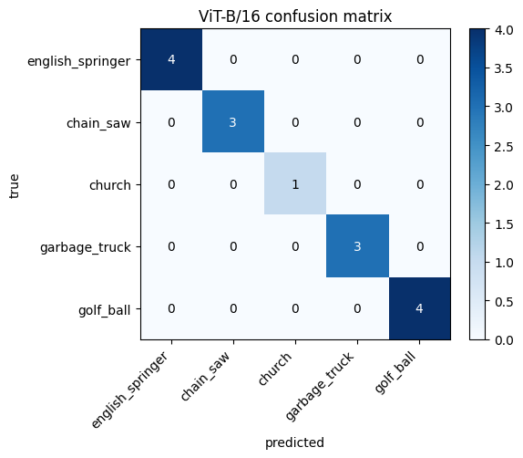

```
predictions falling outside the 5 categories, per row: [0, 1, 3, 1, 0]
```

# Project 1, Part 1: Understanding a Pretrained Vision Transformer

Model: torchvision `vit_b_16`, `ViT_B_16_Weights.IMAGENET1K_V1` Environment: torch 2.0.0+cu117, torchvision 0.15.1+cu117, CPU Preprocessing: the checkpoint's own `weights.transforms()` — resize 256, center crop 224, normalize with ImageNet mean/std, bilinear interpolation.

Image source: Imagenette (fast.ai), a 10-class subset of ImageNet-1k validation images, distributed under the ImageNet terms for non-commercial research and educational use. Five classes were selected and the first four images of each were taken, giving 20 images total.

## Task 1: Image patches and model inputs

A 224x224 input divided into non-overlapping 16x16 patches gives a 14x14 grid:

- patches = (224/16) x (224/16) = 14 x 14 = **196**
- sequence length after prepending the CLS token = **197**

### Patch projection

Each 16x16x3 patch is flattened to a 768-dimensional vector and passed through a single learned linear layer that maps it to the model's embedding dimension (768 for ViT-B/16). This projection is implemented as a convolution with kernel size 16 and stride 16, which is mathematically equivalent to slicing patches and applying a shared linear map. It is learned during pretraining.

### Positional embeddings

Self-attention is permutation-invariant: shuffling the 197 tokens would produce the same set of outputs in shuffled order. Nothing in the attention computation encodes that patch 0 is top-left and patch 195 is bottom-right. A learned positional embedding vector is therefore added to each token so the model can use spatial arrangement.

### CLS token

A single learned vector is prepended to the patch sequence. It carries no image content of its own, but it participates in every attention layer and therefore accumulates information from all patches. The classification head reads only this token's final representation. It provides a fixed-size summary independent of how many patches the input produces.

### Relation to the visualization above

The grid shown is a direct spatial slicing of the preprocessed pixel tensor, written for this report. It shows what the model receives before any learned computation. It is **not** the model's patch projection: the projection maps each patch to a 768-dimensional embedding using weights learned during pretraining, and those embeddings are not images and cannot be displayed as the grid above is. The visualization illustrates the tokenization geometry, not the learned representation.

## Task 2: Predictions on a small image collection

### Label mapping

| Folder | ImageNet index | Label string |
| --- | --- | --- |
| english_springer | 217 | English springer |
| chain_saw | 491 | chain saw |
| church | 497 | church |
| garbage_truck | 569 | garbage truck |
| golf_ball | 574 | golf ball |

### Results

**Top-1 accuracy: 15/20 = 0.750**

| Category | Correct |
| --- | --- |
| English springer | 4/4 |
| chain saw | 3/4 |
| church | 1/4 |
| garbage truck | 3/4 |
| golf ball | 4/4 |

The confusion matrix restricted to these five categories is purely diagonal: every incorrect prediction fell **outside** the five-category set rather than onto another category in it. Counting predictions outside the set per row gives [0, 1, 3, 1, 0], which accounts for all five errors. The model never mistook one of these categories for another; it chose a sixth class from the full 1000-class label space instead. A confusion matrix limited to the five categories would therefore be misleading on its own.

### Successful examples

`golf_ball/ILSVRC2012_val_00007755.JPEG` — correct at 0.916. The runners-up (tennis ball, thimble, buckeye, croquet ball) are all small round objects, so the model's uncertainty is distributed over shape-similar classes, which is a sensible failure mode even where there is no failure.

### Incorrect and uncertain examples

`church/ILSVRC2012_val_00005598.JPEG` — predicted **alp** (0.663), with church only fourth at 0.019. The image is a church in a mountainous landscape, and the model keyed on the dominant scene content rather than the building. This is a foreground/background ambiguity, not a recognition failure in the ordinary sense: both labels describe something genuinely present.

`church/ILSVRC2012_val_00004939.JPEG` — predicted **monastery** (0.624), with church second at 0.241. `church`, `monastery`, and `bell cote` are all distinct ImageNet classes describing overlapping visual concepts. A monastery is frequently a church-like building; the distinction is functional rather than visual, and in many cases cannot be resolved from the image alone.

`chain_saw/ILSVRC2012_val_00004034.JPEG` — predicted **mousetrap** (0.578), with chain saw second at 0.077. This is the clearest genuine error; the top prediction shares neither function nor obvious appearance with the true class.

`garbage_truck/ILSVRC2012_val_00004119.JPEG` — predicted **snowplow** (0.431), with garbage truck second at 0.191 and tow truck third at 0.129. The top three are all large utility vehicles, so the model identified the category of object correctly and failed only on the specific type.

### How fixed output categories constrain the model

**Anything outside the vocabulary is unreachable.** The model cannot indicate that an image contains an object it has no class for; the softmax must distribute mass over the 1000 available options regardless.

**Only object identity can be queried.** The model cannot be asked about actions, spatial relationships, attributes, counts, or relations between objects. The `alp` prediction illustrates this: the model had no way to express "a church in a mountain landscape," only to pick whichever single label scored highest.

These limitations motivate Part 2. CLIP replaces the fixed label set with arbitrary text, so the candidate set becomes a choice made at inference time rather than a property of the trained model.